# Remote Work

## Disability

Having a disability or chronic illness had little effect on the types of struggles workers experience.

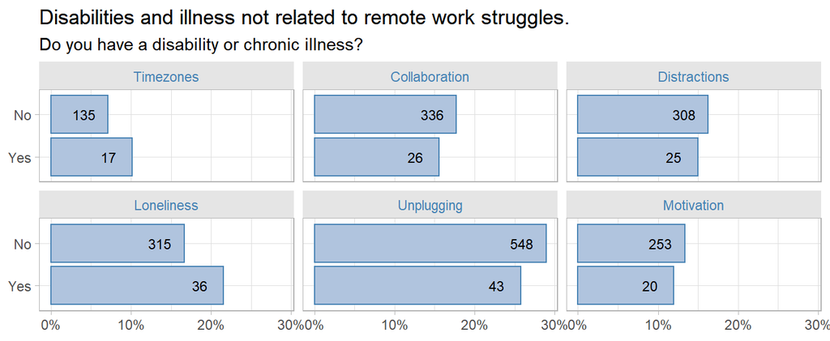

```r
buffer %>% plot_prop("disability",
                     "Disabilities and illness not related to remote work struggles.")
```

## Caregivers

Parents and caregivers were much more likely to struggle with distractions. The upside is that they were also less likely to feel lonely.

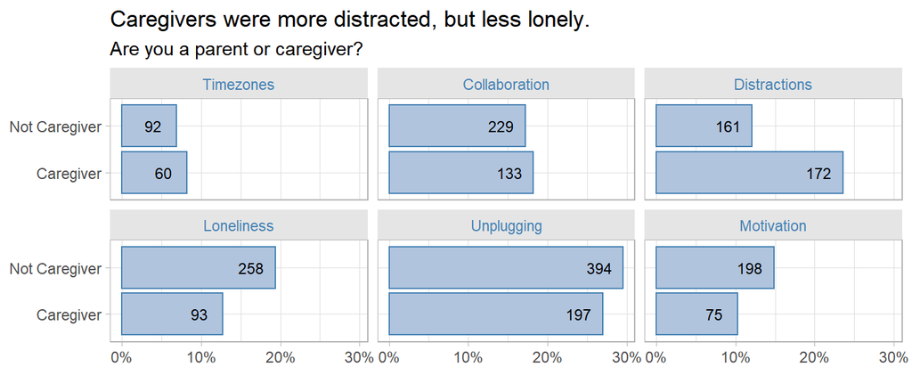

```r
buffer %>% plot_prop("caregiver",
                     "Caregivers were more distracted, but less lonely.")
```

## Full-time Employees

Smaller organizations struggle with distractions, motivation; bigger with unplugging

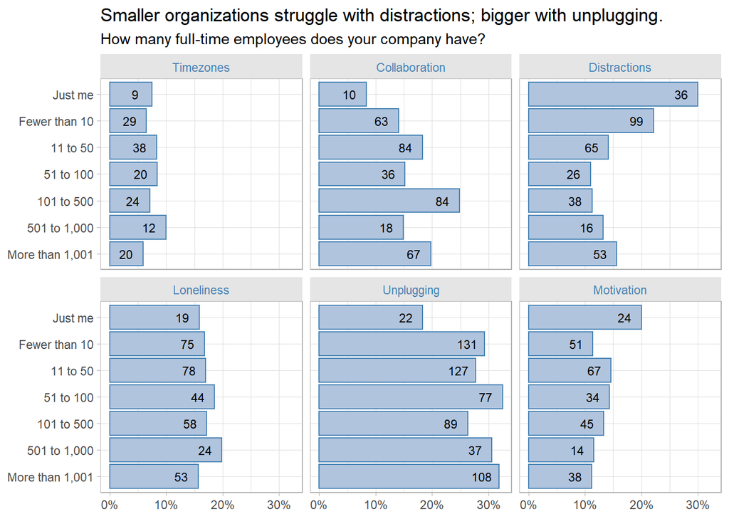

```r
buffer %>% plot_prop("fte",
                     "Smaller organizations struggle with distractions; bigger with unplugging.")
```

## Industry

Struggles are farely common across industries. Government predictably does not deal with time zone issues.

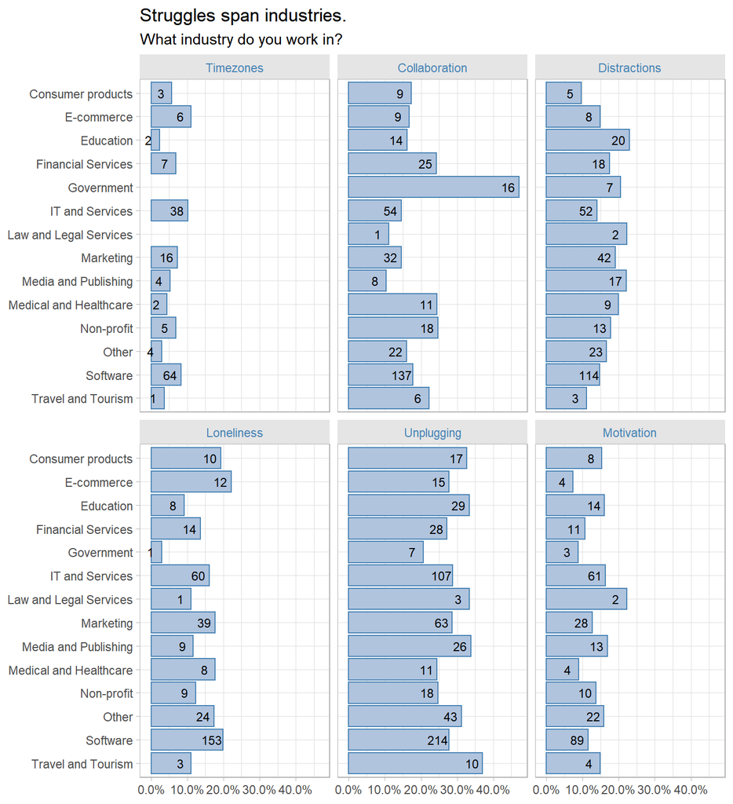

```r
buffer %>% plot_prop("industry",
                     "Struggles span industries.")
```

## Role

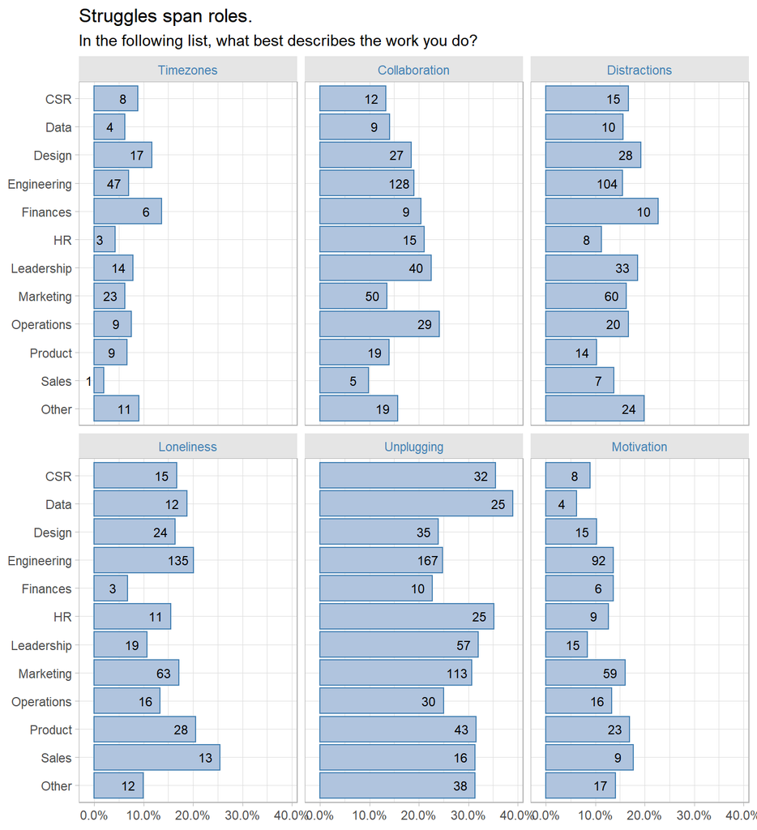

```r
buffer %>% plot_prop("role",
                     "Struggles span roles.")
```

```r
# mtrx_race <- buffer %>% count(struggle, level = race) %>%
#   group_by(level) %>%
#   mutate(pct = n / sum(n)) %>%
#   filter(n >= 10 & )
#   pivot_wider(names_from = struggle, values_from = n) %>%
#   mutate(level = as.character(level))
# mtrx_work <- buffer %>% count(struggle, level = work_exp) %>%
#   pivot_wider(names_from = struggle, values_from = n) %>%
#   mutate(level = as.character(level)
#
# mtrx <- bind_rows(Race = mtrx_race,
#                   `Work Experience` = mtrx_work,
#                   .id = "Factor")
#
# mtrx %>%
#   flextable() %>%
#   merge_v(j = 1) %>%
#   autofit() %>%
#   theme_zebra()
```